# tmp

- **Name**: `HandingOver`
- **Fully Qualified Name**: `org.openprovenance.templates.responsibility.HandingOver`
- **IRI**: https://openprovenance.org/templates/org/openprovenance/templates/responsibility/HandingOver
- **Purpose**: This template describes how responsibility over an entity is passed from one agent to another.
- **Context**: The template describes the operation in which an agent hands over an item to another agent, in effect passing on responsibility, or custody, of this item to the other agent.
- **Design considerations**: The ability to assert new attributes for this entity following the handover.
- **Automation**: ttfs/config-responsibility-handingover.json

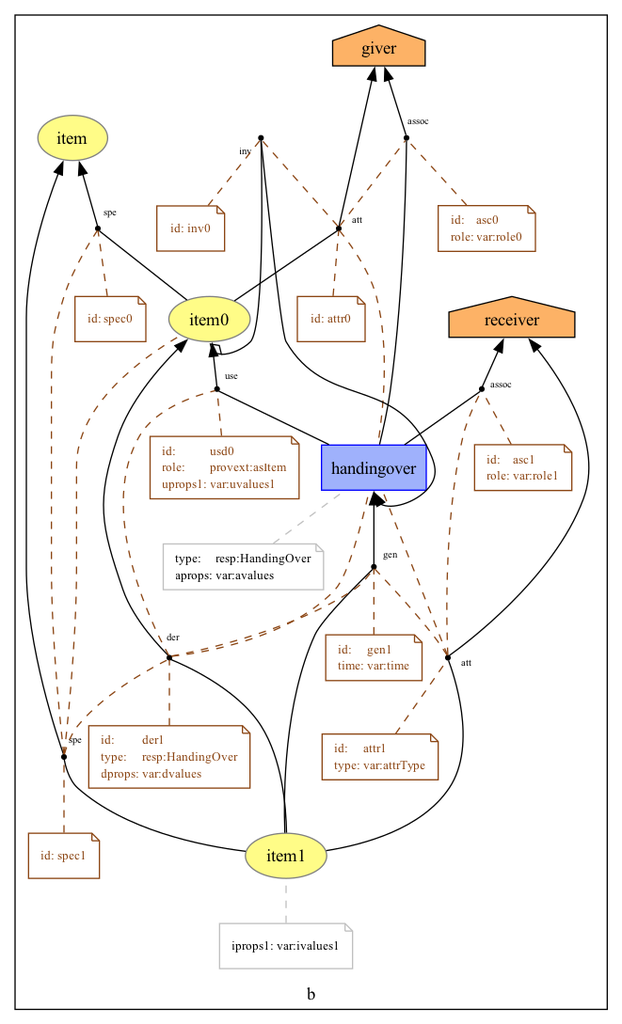

Figure 1: org.openprovenance.templates.responsibility.HandingOver

- **Details**:

  At the start, there is an entity `item` and its specialisation `item0`, with no attributes specified in this template. An activity `handingover` uses entity `item0`. After this operation, an entity `item1` is created with a new attribute `iprops1` and a value `ivalues1`, determined by the activity `handingover`. All other attributes of `item` and `item0` are expected to remain unchanged.

  The template results from merging four instantiated templates.
  - Triangle1-Entity-UGD describing the entity `item0` evolving to `item1` enriched with attribute-value pair `iprops1`-`ivalues1`. All other aspects of the entity `item0` remain unchanged.
  - Triangle2-Entity-SDS describes how the entities `item0` and `item1` are specialisations of a more general entity `item`.
  - Triangle3-AGA describes how the `receiver` agent is involved in the activity, resulting in the agent being linked to `item1` by means of an attribution link.
  - Triangle4-AIA describes how the `giver` agent is responsible for the invalidation of `item0` by the very fact of handing it over to the `receiver` agent.

  Before the activity, `item0` and `receiver` were not linked by an attribution relation; after the activity, `item1` has an attribution to `receiver`, but has lost its attribution link to `giver`. Once `item1` is generated, `item0` reaches the end of its lifetime, marked by the invalidation relation.